# Zadanie domowe - EDA Danych dotyczących Irysów

- Twoim zadaniem jest wykonanie analizy danych zawartych w załączonym pliku CSV (`25__iris.csv`).
- Plik znajduje się pod video. Pamiętaj, żeby wrzucić plik do tego samego folderu, w którym znajduje się ten notebook.
- Wykorzystaj nowo nabytą wiedzę z biblioteki `Pandas`
- Jeżeli jest taka konieczność posiłkuj się [code explainerem](https://codeexplainer.imprv.ai/) lub / i [data chatterem](https://datachatter.imprv.ai/) (który również te dane ma dostępne).
- Prześlij na discordzie notebook z rozwiązaniem (`#modul-4-zad1`)
- Pamiętaj:
1. Nie spiesz się
2. Potraktuj zadanie domowe jak prawdziwy projekt
3. Dodawaj opisy, obserwacje, wnioski
4. Dodaj wizualizacje
5. Dodaj konkluzję i wnioski końcowe

Powodzenia!!! I mega zabawy!

## O Danych

Zbiór danych zawiera informacje o trzech gatunkach irysów: Iris setosa, Iris versicolor, i Iris virginica.

Dane obejmują pomiary czterech cech: długość i szerokość działki kielicha oraz długość i szerokość płatka.

Każdy wiersz w zbiorze danych reprezentuje pojedynczy kwiat, a wartości pomiarów są podane w centymetrach.

Zbiór składa się z 150 próbek, po 50 dla każdego gatunku, i jest szeroko stosowany jako podstawowy zbiór danych do testowania algorytmów klasyfikacji oraz w nauce o danych i uczeniu maszynowym.

Kolumny:

- **długość kielicha (sepal length)** - Długość kielicha w cm
- **szerokość kielicha (sepal width)** - Szerokość kielicha w cm
- **długość płatka (petal length)** - Długość płatka w cm
- **szerokość płatka (petal width)** - Szerokość płatka w cm
- **klasa (class)** - Klasa irysa (setosa, versicolor, virginica)

```python
import pandas as pd
import matplotlib.pyplot as plt #importujemy biblioteki porzebne do przedstawiania
import seaborn as sns #rysunków korelacji
import numpy as np
```

```python
df = pd.read_csv('25__iris.csv', sep=",")
```

# 1. Ogólny przegląd danych i analiza brakujących wartości.

[figure not shown]

### Powyżej trzy gatunki z rodziny Iris. Zbiór danych ich wymiarów jest przedmiotem naszej analizy.

```python
df.sample(10) #Rzut okiem na 10 losowych wierszy
```

|  | długość kielicha (sepal length) | szerokość kielicha (sepal width) | długość płatka (petal length) | szerokość płatka (petal width) | klasa (class) |
| --- | --- | --- | --- | --- | --- |
| 3 | 4.6 | 3.1 | 1.5 | 0.2 | Iris-setosa |
| 128 | 6.4 | 2.8 | 5.6 | 2.1 | Iris-virginica |
| 136 | 6.3 | 3.4 | 5.6 | 2.4 | Iris-virginica |
| 119 | 6.0 | 2.2 | 5.0 | 1.5 | Iris-virginica |
| 134 | 6.1 | 2.6 | 5.6 | 1.4 | Iris-virginica |
| 63 | 6.1 | 2.9 | 4.7 | 1.4 | Iris-versicolor |
| 53 | 5.5 | 2.3 | 4.0 | 1.3 | Iris-versicolor |
| 39 | 5.1 | 3.4 | 1.5 | 0.2 | Iris-setosa |
| 57 | 4.9 | 2.4 | 3.3 | 1.0 | Iris-versicolor |
| 95 | 5.7 | 3.0 | 4.2 | 1.2 | Iris-versicolor |

### Powyżej 10 losowych wierszy zbioru danych

Rzucają się w oczy małe wartości Iris-setosa jeśli chodzi o płatek. Natomiast wartości kielicha w stosunku do innych Irysów są w "normie". Wyróżnia się także Iris-virginica z najdłuższym kielichem w zestawieniu oraz najdłuższym płatkiem. Pierwsza hipoteza - Iris-virginica okaże się największym rozmiarowo gatunkiem a iris-setosa najmniejszym, miejsce pomiędzy nimi zajmie iris-versicolor. Szczegółowa analiza wszystkich danych powinna wykazać czy hipoteza była trafiona.

```python
df.columns # Wyświetlamy listę kolumn, przyda się to nam do zmiany
# ich kolejności.
for column in df.columns: # Wyświetlamy je jedna pod drugą, żeby były bardziej
    print(column) # czytelne - przy użyciu pętli for
```

```
długość kielicha (sepal length)
szerokość kielicha (sepal width)
długość płatka (petal length)
szerokość płatka (petal width)
klasa (class)
```

### Wyświetlamy listę kolumn.

```python
df.index #drukujemy index
```

```
RangeIndex(start=0, stop=150, step=1)
```

Sprawdzamy numer początkowy i ostatni i przeskok między kolejnymi rekordami.

```python
df.head(10) # Wyświetlamy 10 pierwszych rekordów
```

|  | długość kielicha (sepal length) | szerokość kielicha (sepal width) | długość płatka (petal length) | szerokość płatka (petal width) | klasa (class) |
| --- | --- | --- | --- | --- | --- |
| 0 | 5.1 | 3.5 | 1.4 | 0.2 | Iris-setosa |
| 1 | 4.9 | 3.0 | 1.4 | 0.2 | Iris-setosa |
| 2 | 4.7 | 3.2 | 1.3 | 0.2 | Iris-setosa |
| 3 | 4.6 | 3.1 | 1.5 | 0.2 | Iris-setosa |
| 4 | 5.0 | 3.6 | 1.4 | 0.2 | Iris-setosa |
| 5 | 5.4 | 3.9 | 1.7 | 0.4 | Iris-setosa |
| 6 | 4.6 | 3.4 | 1.4 | 0.3 | Iris-setosa |
| 7 | 5.0 | 3.4 | 1.5 | 0.2 | Iris-setosa |
| 8 | 4.4 | 2.9 | 1.4 | 0.2 | Iris-setosa |
| 9 | 4.9 | 3.1 | 1.5 | 0.1 | Iris-setosa |

### Wyświetlamy pierwszych 10 rekordów.

```python
liczba_rekordów_w_klasie = df['klasa (class)'].value_counts()
print(liczba_rekordów_w_klasie)
```

```
Iris-setosa        50
Iris-versicolor    50
Iris-virginica     50
Name: klasa (class), dtype: int64
```

```
Zgodnie z zadeklarowanymi danymi - mamy 50 próbek dla każdego gatunku.
```

```python
df.info() #Wyświetlamy podsumowanie dla kolumn
```

```
<class 'pandas.core.frame.DataFrame'>
RangeIndex: 150 entries, 0 to 149
Data columns (total 5 columns):
 #   Column                            Non-Null Count  Dtype
---  ------                            --------------  -----
 0   długość kielicha (sepal length)   150 non-null    float64
 1   szerokość kielicha (sepal width)  150 non-null    float64
 2   długość płatka (petal length)     150 non-null    float64
 3   szerokość płatka (petal width)    150 non-null    float64
 4   klasa (class)                     150 non-null    object
dtypes: float64(4), object(1)
memory usage: 6.0+ KB
```

Mamy:

1. 5 kolumn w tych danych.
2. Dane są w 100% kompletne.
3. Każdy wiersz zawiera jakąś wartość liczbową.
4. Nie potrzebujemy transformacji danych poza zmianą kolejności kolumny klasa.

```python
df.isnull().sum() #Sprawdza czy są jakieś puste rekordy i zwraca ich ilość
```

```
długość kielicha (sepal length)     0
szerokość kielicha (sepal width)    0
długość płatka (petal length)       0
szerokość płatka (petal width)      0
klasa (class)                       0
dtype: int64
```

Jak widzimy nasz baza danych dla tych trzech roślin jest w 100% kompletna zgodnie z tym co "dostawca danych" pisał.

```python
# df.duplicated().sum()#Sprawdzamy ile mamy duplikatów w danych.
duplikaty = df.duplicated() # Wyświetlamy tylko te wiersze, które są duplikatami
pokaż_duplikaty = df[duplikaty]
print(pokaż_duplikaty)
```

[output not shown]

```
                Istnieją tylko trzy duplikaty
```

```python
df = df[['klasa (class)','długość kielicha (sepal length)',
    'szerokość kielicha (sepal width)','długość płatka (petal length)',
    'szerokość płatka (petal width)']] #Zmieniamy kolejność kolumn, tak żeby
# klasa była umieszczana w pierwszej kolumnie
```

Zmieniamy kolejność kolumn - klasa będzie w pierwszej kolumnie.

```python
df.sample(10) #Wyświetlamy 10 losowych wierszy
```

|  | klasa (class) | długość kielicha (sepal length) | szerokość kielicha (sepal width) | długość płatka (petal length) | szerokość płatka (petal width) |
| --- | --- | --- | --- | --- | --- |
| 4 | Iris-setosa | 5.0 | 3.6 | 1.4 | 0.2 |
| 97 | Iris-versicolor | 6.2 | 2.9 | 4.3 | 1.3 |
| 112 | Iris-virginica | 6.8 | 3.0 | 5.5 | 2.1 |
| 60 | Iris-versicolor | 5.0 | 2.0 | 3.5 | 1.0 |
| 56 | Iris-versicolor | 6.3 | 3.3 | 4.7 | 1.6 |
| 119 | Iris-virginica | 6.0 | 2.2 | 5.0 | 1.5 |
| 75 | Iris-versicolor | 6.6 | 3.0 | 4.4 | 1.4 |
| 93 | Iris-versicolor | 5.0 | 2.3 | 3.3 | 1.0 |
| 15 | Iris-setosa | 5.7 | 4.4 | 1.5 | 0.4 |
| 16 | Iris-setosa | 5.4 | 3.9 | 1.3 | 0.4 |

Rzucają się w oczy małe wartości Iris-setosa jeśli chodzi o płatek. Natomiast wartości kielicha w stosunku do innych Irysów są w "normie". Wyróżnia się także Iris-virginica z najdłuższym kielichem w zestawieniu oraz najdłuższym płatkiem. Pierwsza hipoteza - Iris-virginica okaże się największym rozmiarowo gatunkiem a iris-setosa najmniejszym, miejsce pomiędzy nimi zajmie iris-versicolor. Szczegółowa analiza wszystkich danych powinna wykazać czy hipoteza była trafiona.

```
     Sprawdzamy największe wartości i najmniejsze w każdej kolumnie...
```

```python
df.sort_values(by="długość kielicha (sepal length)", ascending=False).head(10)
# Sortujemy dane malejąco po kolumnie długość kielicha i wyświetlamy 10
# pierwszych wierszy
```

|  | klasa (class) | długość kielicha (sepal length) | szerokość kielicha (sepal width) | długość płatka (petal length) | szerokość płatka (petal width) |
| --- | --- | --- | --- | --- | --- |
| 131 | Iris-virginica | 7.9 | 3.8 | 6.4 | 2.0 |
| 135 | Iris-virginica | 7.7 | 3.0 | 6.1 | 2.3 |
| 122 | Iris-virginica | 7.7 | 2.8 | 6.7 | 2.0 |
| 117 | Iris-virginica | 7.7 | 3.8 | 6.7 | 2.2 |
| 118 | Iris-virginica | 7.7 | 2.6 | 6.9 | 2.3 |
| 105 | Iris-virginica | 7.6 | 3.0 | 6.6 | 2.1 |
| 130 | Iris-virginica | 7.4 | 2.8 | 6.1 | 1.9 |
| 107 | Iris-virginica | 7.3 | 2.9 | 6.3 | 1.8 |
| 125 | Iris-virginica | 7.2 | 3.2 | 6.0 | 1.8 |
| 109 | Iris-virginica | 7.2 | 3.6 | 6.1 | 2.5 |

```
                Najdłuższe kielichy malejąco.
```

```python
df.sort_values(by="szerokość kielicha (sepal width)", ascending=False).head(10)

# Sortujemy dane malejąco po kolumnie szerokość kielicha i wyświetlamy
# 10 pierwszych wierszy
```

|  | klasa (class) | długość kielicha (sepal length) | szerokość kielicha (sepal width) | długość płatka (petal length) | szerokość płatka (petal width) |
| --- | --- | --- | --- | --- | --- |
| 15 | Iris-setosa | 5.7 | 4.4 | 1.5 | 0.4 |
| 33 | Iris-setosa | 5.5 | 4.2 | 1.4 | 0.2 |
| 32 | Iris-setosa | 5.2 | 4.1 | 1.5 | 0.1 |
| 14 | Iris-setosa | 5.8 | 4.0 | 1.2 | 0.2 |
| 16 | Iris-setosa | 5.4 | 3.9 | 1.3 | 0.4 |
| 5 | Iris-setosa | 5.4 | 3.9 | 1.7 | 0.4 |
| 19 | Iris-setosa | 5.1 | 3.8 | 1.5 | 0.3 |
| 44 | Iris-setosa | 5.1 | 3.8 | 1.9 | 0.4 |
| 46 | Iris-setosa | 5.1 | 3.8 | 1.6 | 0.2 |
| 131 | Iris-virginica | 7.9 | 3.8 | 6.4 | 2.0 |

```
                Najszersze kielichy malejąco
```

```python
df.sort_values(by="długość płatka (petal length)", ascending=False).head(10)
# Sortujemy dane malejąco po koluknie - szerokość kielicha i
# wyświetlamy 10 pierwszych wierszy
```

|  | klasa (class) | długość kielicha (sepal length) | szerokość kielicha (sepal width) | długość płatka (petal length) | szerokość płatka (petal width) |
| --- | --- | --- | --- | --- | --- |
| 118 | Iris-virginica | 7.7 | 2.6 | 6.9 | 2.3 |
| 122 | Iris-virginica | 7.7 | 2.8 | 6.7 | 2.0 |
| 117 | Iris-virginica | 7.7 | 3.8 | 6.7 | 2.2 |
| 105 | Iris-virginica | 7.6 | 3.0 | 6.6 | 2.1 |
| 131 | Iris-virginica | 7.9 | 3.8 | 6.4 | 2.0 |
| 107 | Iris-virginica | 7.3 | 2.9 | 6.3 | 1.8 |
| 130 | Iris-virginica | 7.4 | 2.8 | 6.1 | 1.9 |
| 109 | Iris-virginica | 7.2 | 3.6 | 6.1 | 2.5 |
| 135 | Iris-virginica | 7.7 | 3.0 | 6.1 | 2.3 |
| 100 | Iris-virginica | 6.3 | 3.3 | 6.0 | 2.5 |

```
                Najdłuższe płatki malejąco
```

```python
df.sort_values(by="szerokość płatka (petal width)", ascending=False).head(10)
# Sortujemy dane malejąco po kolumnie - szerokość płatka i wyświetlamy
# pierwszych 10 wierszy
```

|  | klasa (class) | długość kielicha (sepal length) | szerokość kielicha (sepal width) | długość płatka (petal length) | szerokość płatka (petal width) |
| --- | --- | --- | --- | --- | --- |
| 100 | Iris-virginica | 6.3 | 3.3 | 6.0 | 2.5 |
| 109 | Iris-virginica | 7.2 | 3.6 | 6.1 | 2.5 |
| 144 | Iris-virginica | 6.7 | 3.3 | 5.7 | 2.5 |
| 114 | Iris-virginica | 5.8 | 2.8 | 5.1 | 2.4 |
| 140 | Iris-virginica | 6.7 | 3.1 | 5.6 | 2.4 |
| 136 | Iris-virginica | 6.3 | 3.4 | 5.6 | 2.4 |
| 148 | Iris-virginica | 6.2 | 3.4 | 5.4 | 2.3 |
| 115 | Iris-virginica | 6.4 | 3.2 | 5.3 | 2.3 |
| 145 | Iris-virginica | 6.7 | 3.0 | 5.2 | 2.3 |
| 143 | Iris-virginica | 6.8 | 3.2 | 5.9 | 2.3 |

```
                Najszersze płatki malejąco
```

### Podsumowanie czterech sortowań 10 największych wartości w każdej kategorii.

```
                    Największy gatunek
```

- Długość kielicha ->....................Iris-virginica
- Szerokość kielicha -> Iris-setosa
- Długość płatka ->.......................Iris-virginica
- Szerokość płatka ->...................Iris-virginica

  Na razie potwierdza się pierwsza hipoteza że - Iris-virginica okaże się największym rozmiarowo gatunkiem. Można zrobić sortowanie wg najmniejszych wartości, żeby sprawdzić czy najmniejsze okazy będą z gatunku - iris-setosa

```python
df.sort_values(by="długość kielicha (sepal length)", ascending=True).head(10)
# Sortujemy dane rosnąco po kolumnie długość kielicha i wyświetlamy 10
# pierwszych wierszy
```

|  | klasa (class) | długość kielicha (sepal length) | szerokość kielicha (sepal width) | długość płatka (petal length) | szerokość płatka (petal width) |
| --- | --- | --- | --- | --- | --- |
| 13 | Iris-setosa | 4.3 | 3.0 | 1.1 | 0.1 |
| 42 | Iris-setosa | 4.4 | 3.2 | 1.3 | 0.2 |
| 38 | Iris-setosa | 4.4 | 3.0 | 1.3 | 0.2 |
| 8 | Iris-setosa | 4.4 | 2.9 | 1.4 | 0.2 |
| 41 | Iris-setosa | 4.5 | 2.3 | 1.3 | 0.3 |
| 22 | Iris-setosa | 4.6 | 3.6 | 1.0 | 0.2 |
| 3 | Iris-setosa | 4.6 | 3.1 | 1.5 | 0.2 |
| 6 | Iris-setosa | 4.6 | 3.4 | 1.4 | 0.3 |
| 47 | Iris-setosa | 4.6 | 3.2 | 1.4 | 0.2 |
| 2 | Iris-setosa | 4.7 | 3.2 | 1.3 | 0.2 |

```python
df.sort_values(by="szerokość kielicha (sepal width)", ascending=True).head(10)

# Sortujemy dane rosnąco po kolumnie szerokość kielicha i wyświetlamy
# 10 pierwszych wierszy
```

|  | klasa (class) | długość kielicha (sepal length) | szerokość kielicha (sepal width) | długość płatka (petal length) | szerokość płatka (petal width) |
| --- | --- | --- | --- | --- | --- |
| 60 | Iris-versicolor | 5.0 | 2.0 | 3.5 | 1.0 |
| 62 | Iris-versicolor | 6.0 | 2.2 | 4.0 | 1.0 |
| 119 | Iris-virginica | 6.0 | 2.2 | 5.0 | 1.5 |
| 68 | Iris-versicolor | 6.2 | 2.2 | 4.5 | 1.5 |
| 41 | Iris-setosa | 4.5 | 2.3 | 1.3 | 0.3 |
| 53 | Iris-versicolor | 5.5 | 2.3 | 4.0 | 1.3 |
| 93 | Iris-versicolor | 5.0 | 2.3 | 3.3 | 1.0 |
| 87 | Iris-versicolor | 6.3 | 2.3 | 4.4 | 1.3 |
| 81 | Iris-versicolor | 5.5 | 2.4 | 3.7 | 1.0 |
| 80 | Iris-versicolor | 5.5 | 2.4 | 3.8 | 1.1 |

```python
df.sort_values(by="długość płatka (petal length)", ascending=True).head(10)
# Sortujemy dane rosnąco po kolumnie - szerokość kielicha i
# wyświetlamy 10 pierwszych wierszy
```

|  | klasa (class) | długość kielicha (sepal length) | szerokość kielicha (sepal width) | długość płatka (petal length) | szerokość płatka (petal width) |
| --- | --- | --- | --- | --- | --- |
| 22 | Iris-setosa | 4.6 | 3.6 | 1.0 | 0.2 |
| 13 | Iris-setosa | 4.3 | 3.0 | 1.1 | 0.1 |
| 14 | Iris-setosa | 5.8 | 4.0 | 1.2 | 0.2 |
| 35 | Iris-setosa | 5.0 | 3.2 | 1.2 | 0.2 |
| 36 | Iris-setosa | 5.5 | 3.5 | 1.3 | 0.2 |
| 40 | Iris-setosa | 5.0 | 3.5 | 1.3 | 0.3 |
| 38 | Iris-setosa | 4.4 | 3.0 | 1.3 | 0.2 |
| 42 | Iris-setosa | 4.4 | 3.2 | 1.3 | 0.2 |
| 2 | Iris-setosa | 4.7 | 3.2 | 1.3 | 0.2 |
| 41 | Iris-setosa | 4.5 | 2.3 | 1.3 | 0.3 |

```python
df.sort_values(by="szerokość płatka (petal width)", ascending=True).head(10)
# Sortujemy dane rosnąco po kolumnie - szerokość płatka i wyświetlamy
# pierwszych 10 wierszy
```

|  | klasa (class) | długość kielicha (sepal length) | szerokość kielicha (sepal width) | długość płatka (petal length) | szerokość płatka (petal width) |
| --- | --- | --- | --- | --- | --- |
| 32 | Iris-setosa | 5.2 | 4.1 | 1.5 | 0.1 |
| 13 | Iris-setosa | 4.3 | 3.0 | 1.1 | 0.1 |
| 37 | Iris-setosa | 4.9 | 3.1 | 1.5 | 0.1 |
| 9 | Iris-setosa | 4.9 | 3.1 | 1.5 | 0.1 |
| 12 | Iris-setosa | 4.8 | 3.0 | 1.4 | 0.1 |
| 34 | Iris-setosa | 4.9 | 3.1 | 1.5 | 0.1 |
| 0 | Iris-setosa | 5.1 | 3.5 | 1.4 | 0.2 |
| 27 | Iris-setosa | 5.2 | 3.5 | 1.5 | 0.2 |
| 28 | Iris-setosa | 5.2 | 3.4 | 1.4 | 0.2 |
| 29 | Iris-setosa | 4.7 | 3.2 | 1.6 | 0.2 |

### Podsumowanie czterech sortowań 10 najmniejszych wartości w każdej kategorii.

```
                        Najmniejszy gatunek
```

- Długość kielicha -> iris-setosa
- Szerokość kielicha -> przeważa iris-versicolor
- Długość płatka -> iris-setosa
- Szerokość płatka -> iris-setosa

Najmniejszych 10 irisów był w trzech kategoriach - iris-setosa. Utrzymuje to hipotezę o najmniejszym gatunku dla iris-setosa.

```python
df.describe() #Wyświetlamy podsumowanie statystyk
# Dobrze by było zaokrąglić wynik do dwóch miejsc po przecinku.
print(df.describe().round(2)) # Ta linijka załatwia sprawę
#Przydałoby się jeszcze przedstawić dane w czytelniejszy sposób z widocznym podziałem
#na wiersze.
```

```
       długość kielicha (sepal length)  szerokość kielicha (sepal width)  \
count                           150.00                            150.00
mean                              5.84                              3.05
std                               0.83                              0.43
min                               4.30                              2.00
25%                               5.10                              2.80
50%                               5.80                              3.00
75%                               6.40                              3.30
max                               7.90                              4.40

       długość płatka (petal length)  szerokość płatka (petal width)
count                         150.00                          150.00
mean                            3.76                            1.20
std                             1.76                            0.76
min                             1.00                            0.10
25%                             1.60                            0.30
50%                             4.35                            1.30
75%                             5.10                            1.80
max                             6.90                            2.50
```

```python
df.nunique() #Wyświetlamy wartości unikatowe
```

```
długość kielicha (sepal length)     35
szerokość kielicha (sepal width)    23
długość płatka (petal length)       43
szerokość płatka (petal width)      22
klasa (class)                        3
dtype: int64
```

### Wartości unikatowe zbioru

1. Najbardziej zróżnicowana jest długość płatka. Warto by zbadać, czy po samym jednym parametrze (długości płatka) możemy rozpoznać do jakiej klasy należy roślina.

```python
grupowanie = df.groupby('klasa (class)')
statystyki = grupowanie.agg(['mean', 'std', 'min', 'max', 'median'])
statystyki
```

| klasa (class) | długość kielicha (sepal length) mean | długość kielicha (sepal length) std | długość kielicha (sepal length) min | długość kielicha (sepal length) max | długość kielicha (sepal length) median | szerokość kielicha (sepal width) mean | szerokość kielicha (sepal width) std | szerokość kielicha (sepal width) min | szerokość kielicha (sepal width) max | szerokość kielicha (sepal width) median | długość płatka (petal length) mean | długość płatka (petal length) std | długość płatka (petal length) min | długość płatka (petal length) max | długość płatka (petal length) median | szerokość płatka (petal width) mean | szerokość płatka (petal width) std | szerokość płatka (petal width) min | szerokość płatka (petal width) max | szerokość płatka (petal width) median |
| --- | --- | --- | --- | --- | --- | --- | --- | --- | --- | --- | --- | --- | --- | --- | --- | --- | --- | --- | --- | --- |
| Iris-setosa | 5.006 | 0.352490 | 4.3 | 5.8 | 5.0 | 3.418 | 0.381024 | 2.3 | 4.4 | 3.4 | 1.464 | 0.173511 | 1.0 | 1.9 | 1.50 | 0.244 | 0.107210 | 0.1 | 0.6 | 0.2 |
| Iris-versicolor | 5.936 | 0.516171 | 4.9 | 7.0 | 5.9 | 2.770 | 0.313798 | 2.0 | 3.4 | 2.8 | 4.260 | 0.469911 | 3.0 | 5.1 | 4.35 | 1.326 | 0.197753 | 1.0 | 1.8 | 1.3 |
| Iris-virginica | 6.588 | 0.635880 | 4.9 | 7.9 | 6.5 | 2.974 | 0.322497 | 2.2 | 3.8 | 3.0 | 5.552 | 0.551895 | 4.5 | 6.9 | 5.55 | 2.026 | 0.274650 | 1.4 | 2.5 | 2.0 |

### Jeśli bierzemy pod uwagę te trzy gatunki i stosunki wymiarów względem siebie to możemy ogólnie zinterpretować je tak:

1. Iris-setosa - krótke i wąskie płatki. Szeroki ale krótki kielich.
2. Iris-versicolor - Średniej długości i szerokości płatek większy od Iris-setosa a mniejszy od Iris-virginica. Natomiast zakres danych szerkokości kielicha pokrywa się z Iris-Virginica w 66,66% a długości kielicha w 70% co utrudnia rozróżnienie tych gatunków w oparciu o te wymiary.
3. Iris-virginica - Egzemplarze tego gatunku potrafią mieć największe wszystkie cztery wymiary z opisywanych tu gatunków. Niestety poza egzemplarzami mające największe wymiary - reszta zbioru pokrywa się wymiarowo z Iris-versicolor w: 26,66% szerokości płatka, 15,3% długości płatka, 66,66% szerkości kielicha, 70,0% długości kielicha, Jak widzimy to wymiary płatka mogą być daną, która w największym stopniu pozwoli rozróżnić te gatunki. Sprawdzimy na wykresie wszystkich próbek w jakim stopniu będzie wymieszanie egzemplarzy tych gatunków.

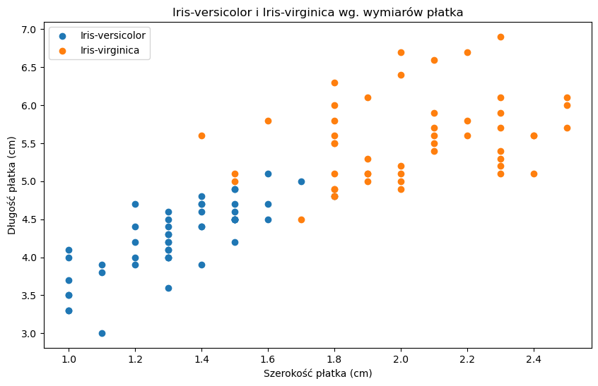

```python
# Filtruje DataFrame wgo dwóch gatunków
filtered_df = df[df['klasa (class)'].isin(['Iris-versicolor', 'Iris-virginica'])]

# Tworzy scatter plot dla długości i szerokości płatka
plt.figure(figsize=(10, 6))
for species in ['Iris-versicolor', 'Iris-virginica']:
    subset = filtered_df[filtered_df['klasa (class)'] == species]
    plt.scatter(subset['szerokość płatka (petal width)'],
                subset['długość płatka (petal length)'], label=species)

# Dodaje tytuły osi i nazwę wykresu
plt.xlabel('Szerokość płatka (cm)')
plt.ylabel('Długość płatka (cm)')
plt.title('Iris-versicolor i Iris-virginica wg. wymiarów płatka')
plt.legend()

# Zapisuje wykres w pliku
plot_filename = 'iris_scatter_plot.png'
plt.savefig(plot_filename)
```

Scatter plot pomógł dostrzec, że 26,66% szerokości płatka, 15,3% długości płatka części wspólnej wymiarów tych dwóch gatunków to bardzo niewiele. Można by przeprowadzić granicę oddzielającą te dwa gatunki jeśli by pominąć ten mały procent egzemplarzy iris-virginica o najmniejszych wymiarach i potraktować je jako wartości odstające. Oba wymiary płatka pozwalają w dużym stopniu rozdzielić i rozpoznawać te gatunki wg. wymiarów płatka.

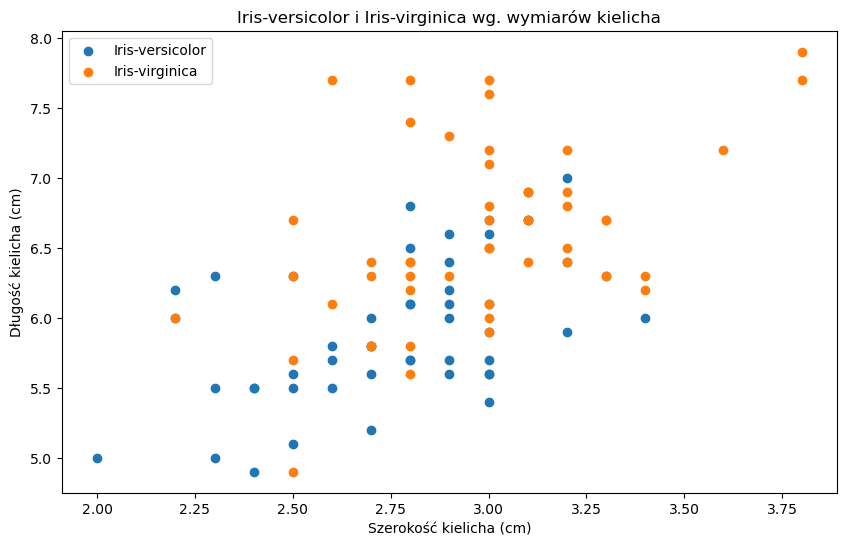

```python
filtered_df = df[df['klasa (class)'].isin(['Iris-versicolor', 'Iris-virginica'])]

# Tworzy scatter plot dla długości i szerokości płatka
plt.figure(figsize=(10, 6))
for species in ['Iris-versicolor', 'Iris-virginica']:
    subset = filtered_df[filtered_df['klasa (class)'] == species]
    plt.scatter(subset['szerokość kielicha (sepal width)'],
                subset['długość kielicha (sepal length)'], label=species)

# Dodaje tytuły osi i nazwę wykresu
plt.xlabel('Szerokość kielicha (cm)')
plt.ylabel('Długość kielicha (cm)')
plt.title('Iris-versicolor i Iris-virginica wg. wymiarów kielicha')
plt.legend()

# Zapisuje wykres w pliku
plot_filename = 'iris_scatter_plot2.png'
plt.savefig(plot_filename)
```

Potwierdziła się wcześniejsza obserwacja. Po wymiarach kielicha nie sposób rozróżnić Iris-versicol od Iris-virginica. Wymiary kielicha dla obu gatunków są ze sobą wymieszane.

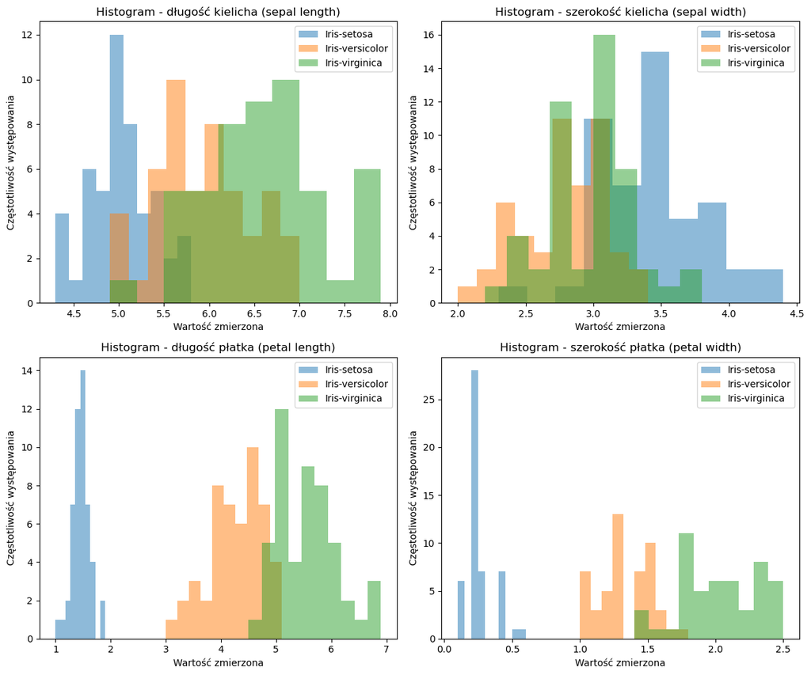

```python
features = ['długość kielicha (sepal length)',
    'szerokość kielicha (sepal width)','długość płatka (petal length)',
    'szerokość płatka (petal width)'] # Określamy które kolumny będą na histogramie


fig, axes = plt.subplots(nrows=2, ncols=2, figsize=(12, 10))
axes = axes.flatten() # Określamy cechy histogramu


for i, feature in enumerate(features):
    for species in df['klasa (class)'].unique():
        subset = df[df['klasa (class)'] == species]
        axes[i].hist(subset[feature], bins=10, alpha=0.5, label=species)
# Tworzymy histogram dla każdej cechy dla każdego unikalnego gatunku w ramce danych.
# Dla każdego gatunku, tworzymy podzbiór ramki danych zawierającej tylko wiersze
# dla tego gatunku, a następnie rysujemy histogram cechy dla tych wierszy.
    axes[i].set_title(f'Histogram - {feature}')
    axes[i].set_xlabel('Wartość zmierzona')
    axes[i].set_ylabel('Częstotliwość występowania')
    axes[i].legend()
# Określamy tytuły każdego wykresu, nazwy osi, dodajemy legendę

plt.tight_layout() # fukcja ta dostosowuje automatycznie odstępy między wykresami


plt.savefig('iris_histograms.png') # zapisujemy wykres w pliku
```

```
                Histogramy dla wszystkich zmierzonych cech Irisów
```

1. Iris-setosa - gatunek, który wyróżnia się najmniejszą długością i szerokością płatka. Może to być cecha rozpoznawalna dla tego gatunku.
2. Długość i szerokość płatka może być brana pod uwagę jak wymierna cecha, według której można z dużym prawdopodobieństwiem rozróżnić wszystkie gatunki. Jest niewielka część wspólna wyników dla Iris-versicolor i iris-virginica
3. Wymiary kielicha powtarzają się w części zmierzonych próbek, przez co nie będzie to wskaźnik, dzięki któremu będziemy rozróżniać te trzy gatunki.

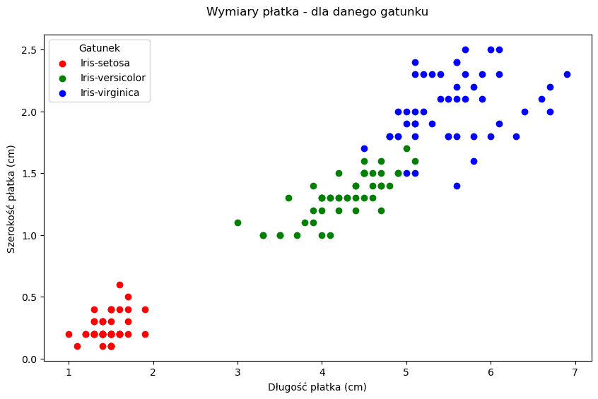

```python
# Tworzymy scatter plot
plt.figure(figsize=(10, 6))

# Malujemy każdą klasę innym kolorem
for species, color in zip(df['klasa (class)'].unique(), ['r', 'g', 'b']):
    subset = df[df['klasa (class)'] == species]
    plt.scatter(subset['długość płatka (petal length)'], subset['szerokość płatka (petal width)'], label=species, color=color)

# Dodajemy etykiety i legendę
plt.xlabel('Długość płatka (cm)')
plt.ylabel('Szerokość płatka (cm)')
plt.title('Wymiary płatka - dla danego gatunku',pad=20) # chcemy mieć
plt.legend(title='Gatunek') # przerwę między tytułem

# Zapisujemy scatter plot do pliku
plt.savefig('iris_scatter_plot.png')
```

Jeszcze widoczniej na tym wykresie - wymiary płatka Iris-setosa różnią się od pozostałych dwóch gatunków.

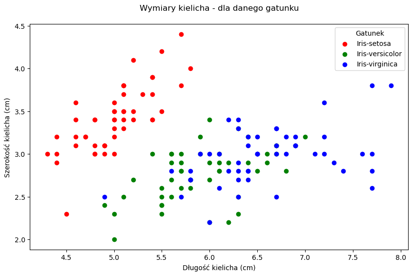

```python
plt.figure(figsize=(10, 6))

# Malujemy każdą klasę innym kolorem
for species, color in zip(df['klasa (class)'].unique(), ['r', 'g', 'b']):
    subset = df[df['klasa (class)'] == species]
    plt.scatter(subset['długość kielicha (sepal length)'], subset
                ['szerokość kielicha (sepal width)'], label=species, color=color)

# Dodajemy etykiety i legendę
plt.xlabel('Długość kielicha (cm)')
plt.ylabel('Szerokość kielicha (cm)')
plt.title('Wymiary kielicha - dla danego gatunku',pad=20) # chcemy mieć
plt.legend(title='Gatunek') # przerwę między tytułem

# Zapisujemy scatter plot do pliku
plt.savefig('iris_scatter_plot2.png')
```

Iris-setosa wyróżnia się z pośród trzech gatunków, choć długość i szerokość kielicha nie są już tu tak unikalne jak w przypadku wymiarów płatka, przez co wartości kielicha nie mogą być cechą dzięki której będziemy mogli rozróżnić te trzy gatunki.

# 5. Analiza relacji mmiędzy zmiennymi.

Zbadamy relację długości do szerokości kielicha jak i płatka dla każdego gatunku.

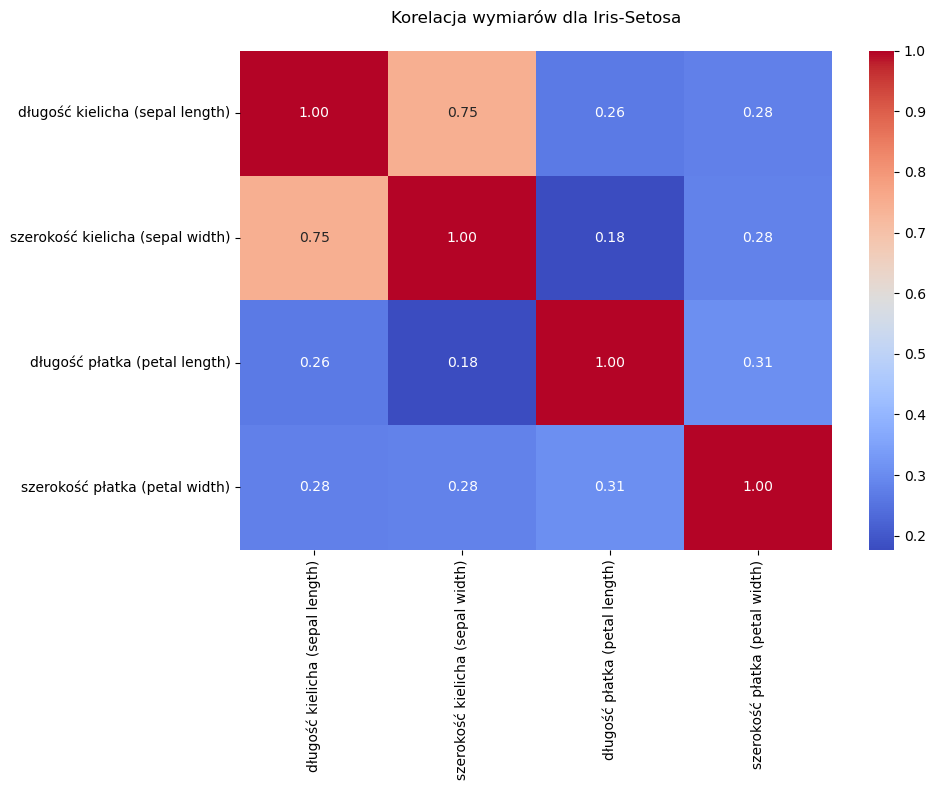

```python
iris_setosa_df = df[df['klasa (class)'] == 'Iris-setosa']


correlation_matrix = iris_setosa_df.corr(numeric_only = True)


plt.figure(figsize=(10, 8))
sns.heatmap(correlation_matrix, annot=True, cmap='coolwarm', fmt=".2f")
plt.title('Korelacja wymiarów dla Iris-Setosa', pad=20)
plt.tight_layout()


plot_filename = "Korelacja wymiarów dla Iris-Setosa.png"
plt.savefig(plot_filename)
```

W przypadku gatunku Iris-Setosa widzimy występującą korelację (nie jest ona bardzo mocna) między szerokością kielicha a długością kielicha. Oznacza to że im dłuższy kielich tym jest zarazem szerszy.

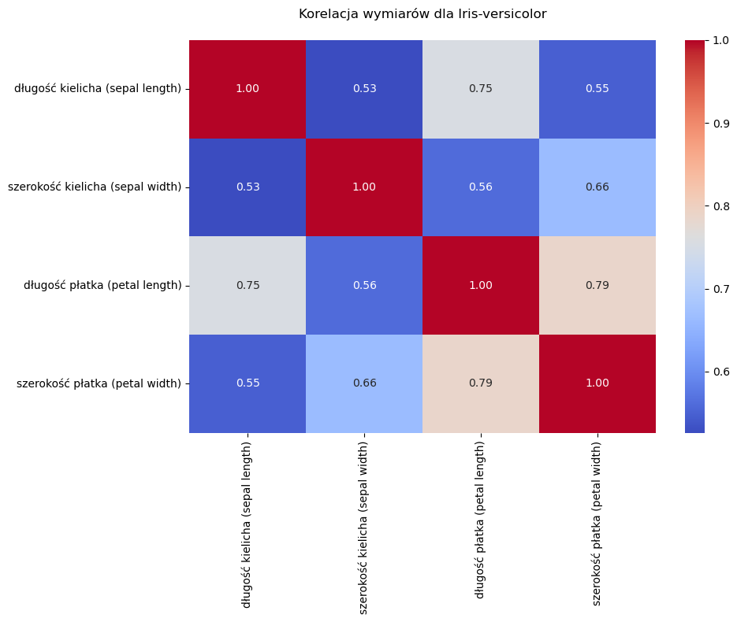

```python
iris_versicolor_df = df[df['klasa (class)'] == 'Iris-versicolor']


correlation_matrix = iris_versicolor_df.corr(numeric_only=True)


plt.figure(figsize=(10, 8))
sns.heatmap(correlation_matrix, annot=True, cmap='coolwarm', fmt=".2f")
plt.title('Korelacja wymiarów dla Iris-versicolor', pad=20)
plt.tight_layout()


plot_filename = "Korelacja wymiarów dla Iris-versicolor.png"
plt.savefig(plot_filename)
```

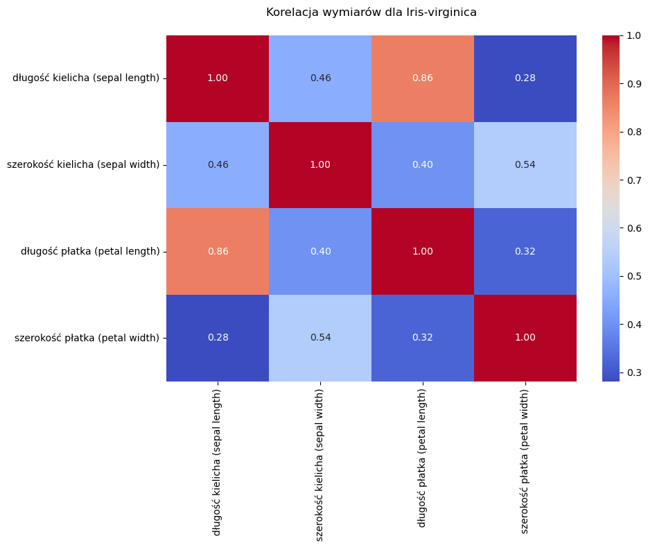

```python
Iris_virginica_df = df[df['klasa (class)'] == 'Iris-virginica']


correlation_matrix = Iris_virginica_df.corr(numeric_only=True)


plt.figure(figsize=(10, 8))
sns.heatmap(correlation_matrix, annot=True, cmap='coolwarm', fmt=".2f")
plt.title('Korelacja wymiarów dla Iris-virginica', pad=20)
plt.tight_layout()


plot_filename = "Korelacja wymiarów dla Iris-virginica.png"
plt.savefig(plot_filename)
```

W przypadku gatunku Iris-virginica widzimy najsilniejszą z wszystkich trzech gatunków korelację między długością kielicha a długością płatka. Im dłuższy kielich w tym gatunku, tym dłuższy jest płatek.

# 6. Analiza wartości odstających.

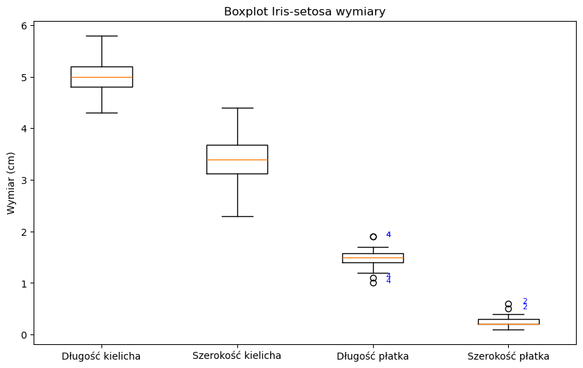

```python
# Filtrujemy DataFrame wg klasy iris-setosa
setosa_df = df[df['klasa (class)'] == 'Iris-setosa']

# Tworzymy boxplot
fig, ax = plt.subplots(figsize=(10, 6))
boxplot = ax.boxplot([setosa_df['długość kielicha (sepal length)'],
                      setosa_df['szerokość kielicha (sepal width)'],
                      setosa_df['długość płatka (petal length)'],
                      setosa_df['szerokość płatka (petal width)']],
                     tick_labels=['Długość kielicha', 'Szerokość kielicha',
                             'Długość płatka', 'Szerokość płatka'],
                     patch_artist=False) #W razie gdybym chciał mieć pokolorowane
                                        #boxploty to dam na True

# Obliczamy i opisujemy liczbę wartości odstających
for i, line in enumerate(boxplot['fliers']):
    ydata = line.get_ydata()
    xdata = line.get_xdata()
    num_outliers = len(ydata)
    for j in range(num_outliers):
        ax.annotate(f'{num_outliers}', xy=(xdata[j], ydata[j]),
                    xytext=(xdata[j] + 0.1, ydata[j]), fontsize=8, color='blue')

# Dodajemy etykiety
ax.set_title('Boxplot Iris-setosa wymiary')
ax.set_ylabel('Wymiar (cm)')

# Zapisujemy bocplot do pliku
plt.savefig('iris_setosa_boxplot.png')
```

# 7.Konkluzja i wnioski końcowe.

# Iris-Setosa

[figure not shown]

Iris-setosa jest gatunkiem, którego charakteryzują krótke i wąskie płatki, oraz szeroki ale krótki kielich. W przypadku gatunku Iris-Setosa widzimy występującą niezbyt mocną korelację między szerokością kielicha a długością kielicha. Oznacza to, że im dłuższy kielich tym jest zarazem szerszy. Iris-setosa - gatunek, który wyróżnia się w porównianiu z pozostałymi Iris-ami najmniejszą długością i szerokością płatka.

# Iris-versicolor

[figure not shown]

# Iris-virginica

[figure not shown]

Iris-virginica okazało się największym rozmiarowo gatunkiem spośród trzech analizowanych. Egzemplarze tego gatunku potrafią mieć największe wszystkie cztery wymiary z opisywanych tu gatunków. W przypadku gatunku Iris-virginica widzimy najsilniejszą z wszystkich trzech gatunków korelację między długością kielicha a długością płatka. Im dłuższy kielich w tym gatunku, tym dłuższy jest płatek.

### Pozostałe notatki - Dane uzupełniające

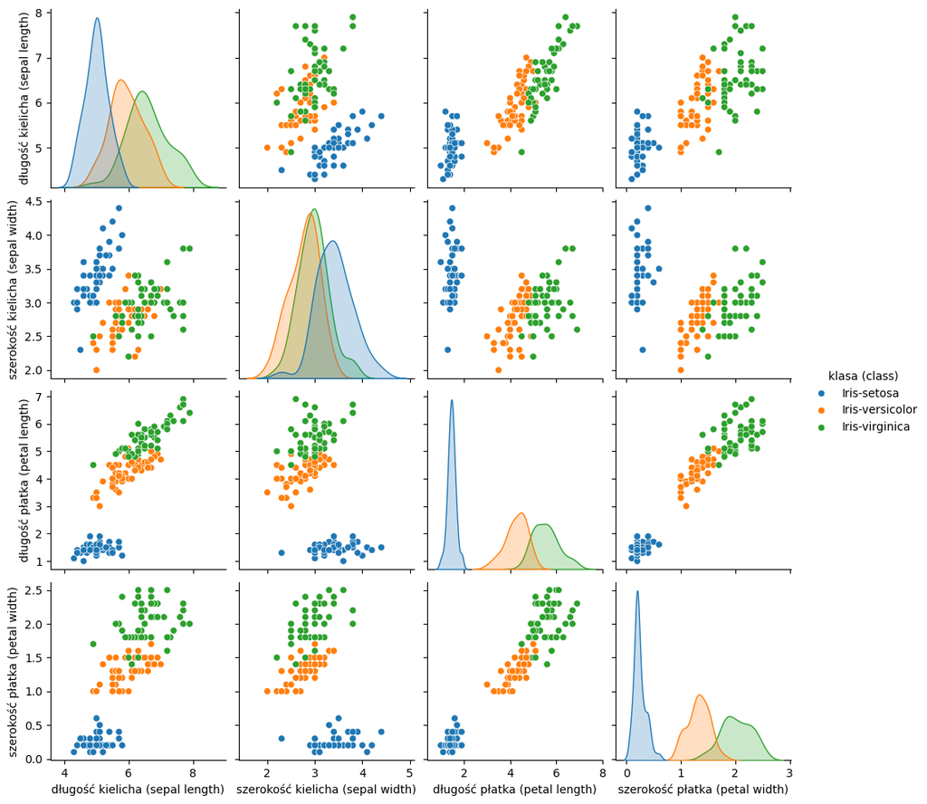

```python
pairplot = sns.pairplot(df, hue='klasa (class)', diag_kind='kde')
plot_filename = "iris_scatter_plot.png"
pairplot.savefig(plot_filename)
result = {"type": "plot", "value": plot_filename }
```

Pairplot dla wszystkich danych wg gatunków.

[figure not shown]

```python
# Set the style of seaborn
sns.set(style="whitegrid")

# Create a figure and axes for the box plots
fig, axes = plt.subplots(2, 2, figsize=(12, 10))
fig.suptitle('Wykresy pudełkowe dla parametrów irysów z linią średniej')

# List of features to plot
features = ['długość kielicha (sepal length)',
            'szerokość kielicha (sepal width)',
            'długość płatka (petal length)', 'długość płatka (petal length)']
titles = ['Długość kielicha', 'Szerokość kielicha', 'Długość płatka', 'Szerokość płatka']

# Iterate over features and create a boxplot for each
for ax, feature, title in zip(axes.flatten(), features, titles):
    sns.boxplot(x='klasa (class)', y=feature, data=df, ax=ax)
    mean_value = df[feature].mean()
    ax.axhline(mean_value, color='r', linestyle='--')
    ax.set_title(title)
    ax.set_xlabel('Klasa')
    ax.set_ylabel('Wartość (cm)')

# Adjust layout
plt.tight_layout(rect=[0, 0.03, 1, 0.95])

# Save the plot as a PNG file
plot_filename = "iris_boxplots_with_mean.png"
plt.savefig(plot_filename)
setosa_df = df[df['klasa (class)'] == 'Iris-setosa']
```

```
       Wykresy pudełkowe dla parametrów irisów z linią średniej.
```